# Week 6: Discrete Probability and Binomial Distribution

## Example 1

On page 249 of the OpenStax textbook, a hospital researcher find number of times x the average post-op patient will ring the nurse during a 12-hour shift. The data are the following.

```r
x <- c(0, 1, 2, 3, 4, 5)
p <- c(4/50, 8/50, 16/50, 14/50, 6/50, 2/50)
```

The expected value is calculated by multiply each value of the random variable by its probability, and then adding the products.

```r
mu <- sum(x*p)
mu
```

```
## [1] 2.32
```

The variance and standard deviation are defined as follows.
$$\sigma^{2} = \sum (x-\mu)^{2} \cdot P(x), \quad
\sigma = \sqrt{\sigma^{2}}$$
Below we implement the formula.

```r
v <- sum((x-mu)^2*p)
sqrt(v)
```

```
## [1] 1.223765
```

We conclude that the mean is 2.32, and the standard deviation is 1.22.

## Example 2

Consider the example on page 256 of the OpenStax textbook, 41% of adult workers have a high school diploma but do not pursue any further education. If 20 adult workers are randomly selected, what is the probability that at most 12 of them have a high school diploma but do not pursue further education?

We can use the dbinom function for this problem. The probabilities for exactly 11 and 12 are the following.

```r
dbinom(11, 20, 0.41)
```

```
## [1] 0.0800749
```

```r
dbinom(12, 20, 0.41)
```

```
## [1] 0.04173395
```

We can use the colon operator to create a sequence from 0 to 12, and use sum to add the probabilities together.

```r
dbinom(0:12, 20, 0.41)
```

```
##  [1] 2.612403e-05 3.630798e-04 2.396942e-03 9.994029e-03 2.951626e-02
##  [6] 6.563617e-02 1.140289e-01 1.584809e-01 1.789625e-01 1.658184e-01
## [11] 1.267527e-01 8.007490e-02 4.173395e-02
```

```r
sum(dbinom(0:12, 20, 0.41))
```

```
## [1] 0.9737849
```

The graph of the binomial probability distribution function is the following.

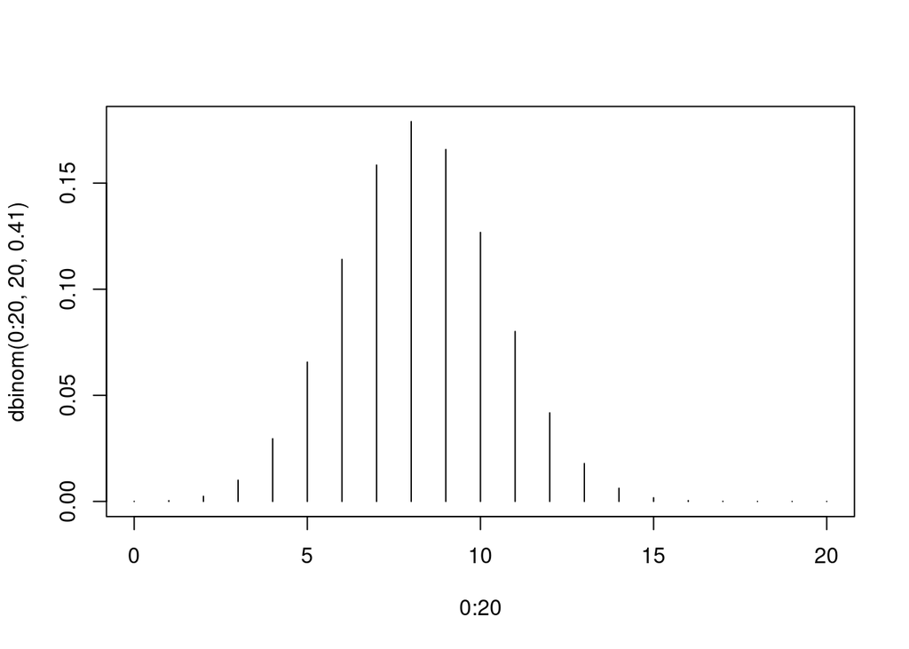

```r
plot(0:20, dbinom(0:20, 20, 0.41), type = "h")
```

## Follow Up

Try the exercise on page 258 of the OpenStax textbook: 60% of American adults prefer saving over spending. Out of a random sample of 50, what is the probability that at most 20 adults prefer saving?

© 2022 Frank Wang